# Case Study: Predicting Employee Absenteeism

## Part 1

### Background

- Absenteeism in the workplace is a challenge that every manager has to address at some point in time.
- Predicting and planning for absenteeism can help managers efficiently allocate resources and maintain productivity.
- This case study explores the “Absenteeism at work” dataset to shed light on this issue.

### Data Description

- The dataset titled “Absenteeism at work” was contributed by Martiniano, Andrea and Ferreira, Ricardo in 2018 and is hosted in the UCI Machine Learning Repository.
- The dataset provides insight into the absenteeism behavior of employees across several factors:
  - Reasons for absence
  - Seasons
  - Transportation expense
  - Distance to work
  - Service time
  - … and more.

### Loading the Necessary Packages

```r
if(!require("pacman")) install.packages("pacman")
pacman::p_load(tidyverse,psych,jtools)
```

**Notes on the Code:**

- This code is a neat way to ensure that certain packages are installed and loaded in an R session, using the `pacman` package for streamlined package management.
- The code starts with a check to see if the `pacman` package is available in the R session.
- The `pacman::p_load` function verifies if certain packages are installed and loads them.
- The `tidyverse` package in R serves as an umbrella, encompassing a suite of R packages tailor-made for data analytics.
  - Packages within the tidyverse include `ggplot2`, `dplyr`, `tidyr`, and `readr`.
- The `psych` package offers a specialized toolkit catered towards psychological, psychometric, and personality research.
  - This package is instrumental for those seeking rudimentary statistical overviews.
- The `jtools` package provides tools for data analysis, primarily tailored for the social sciences in R.

## Part 2

### **Step 1: Load and Clean the Data**

Begin by loading necessary packages and then importing the dataset:

```r
absenteeism_data <- read.csv("https://ljkelly3141.github.io/ABE-Book/data/Absenteeism_at_work.csv",
                             sep = ";")
```

A glance at the first few rows of data will help get a sense of the structure:

```r
rmarkdown::paged_table(absenteeism_data)
```

| ID | Reason.for.absence | Month.of.absence | Day.of.the.week | Seasons | Transportation.expense | Distance.from.Residence.to.Work | Service.time | Age | Work.load.Average.day | Hit.target | Disciplinary.failure | Education | Son | Social.drinker | Social.smoker | Pet | Weight | Height | Body.mass.index | Absenteeism.time.in.hours |
| --- | --- | --- | --- | --- | --- | --- | --- | --- | --- | --- | --- | --- | --- | --- | --- | --- | --- | --- | --- | --- |
| 11 | 26 | 7 | 3 | 1 | 289 | 36 | 13 | 33 | 239.554 | 97 | 0 | 1 | 2 | 1 | 0 | 1 | 90 | 172 | 30 | 4 |
| 36 | 0 | 7 | 3 | 1 | 118 | 13 | 18 | 50 | 239.554 | 97 | 1 | 1 | 1 | 1 | 0 | 0 | 98 | 178 | 31 | 0 |
| 3 | 23 | 7 | 4 | 1 | 179 | 51 | 18 | 38 | 239.554 | 97 | 0 | 1 | 0 | 1 | 0 | 0 | 89 | 170 | 31 | 2 |
| 7 | 7 | 7 | 5 | 1 | 279 | 5 | 14 | 39 | 239.554 | 97 | 0 | 1 | 2 | 1 | 1 | 0 | 68 | 168 | 24 | 4 |
| 11 | 23 | 7 | 5 | 1 | 289 | 36 | 13 | 33 | 239.554 | 97 | 0 | 1 | 2 | 1 | 0 | 1 | 90 | 172 | 30 | 2 |
| 3 | 23 | 7 | 6 | 1 | 179 | 51 | 18 | 38 | 239.554 | 97 | 0 | 1 | 0 | 1 | 0 | 0 | 89 | 170 | 31 | 2 |
| 10 | 22 | 7 | 6 | 1 | 361 | 52 | 3 | 28 | 239.554 | 97 | 0 | 1 | 1 | 1 | 0 | 4 | 80 | 172 | 27 | 8 |
| 20 | 23 | 7 | 6 | 1 | 260 | 50 | 11 | 36 | 239.554 | 97 | 0 | 1 | 4 | 1 | 0 | 0 | 65 | 168 | 23 | 4 |
| 14 | 19 | 7 | 2 | 1 | 155 | 12 | 14 | 34 | 239.554 | 97 | 0 | 1 | 2 | 1 | 0 | 0 | 95 | 196 | 25 | 40 |
| 1 | 22 | 7 | 2 | 1 | 235 | 11 | 14 | 37 | 239.554 | 97 | 0 | 3 | 1 | 0 | 0 | 1 | 88 | 172 | 29 | 8 |

[output cut: 730 more lines]

### **Step 2: Describe the Data**

We’ll leverage the `describe` function from the `psych` package for a detailed summary:

```r
describe(absenteeism_data, ranges = FALSE, skew = FALSE)
```

```
##                                 vars   n   mean    sd   se
## ID                                 1 740  18.02 11.02 0.41
## Reason.for.absence                 2 740  19.22  8.43 0.31
## Month.of.absence                   3 740   6.32  3.44 0.13
## Day.of.the.week                    4 740   3.91  1.42 0.05
## Seasons                            5 740   2.54  1.11 0.04
## Transportation.expense             6 740 221.33 66.95 2.46
## Distance.from.Residence.to.Work    7 740  29.63 14.84 0.55
## Service.time                       8 740  12.55  4.38 0.16
## Age                                9 740  36.45  6.48 0.24
## Work.load.Average.day             10 740 271.49 39.06 1.44
## Hit.target                        11 740  94.59  3.78 0.14
## Disciplinary.failure              12 740   0.05  0.23 0.01
## Education                         13 740   1.29  0.67 0.02
## Son                               14 740   1.02  1.10 0.04
## Social.drinker                    15 740   0.57  0.50 0.02
## Social.smoker                     16 740   0.07  0.26 0.01
## Pet                               17 740   0.75  1.32 0.05
## Weight                            18 740  79.04 12.88 0.47
## Height                            19 740 172.11  6.03 0.22
## Body.mass.index                   20 740  26.68  4.29 0.16
## Absenteeism.time.in.hours         21 740   6.92 13.33 0.49
```

### **Step 3: Summarize the Number of Absences per Month**

To understand the absenteeism patterns better, let’s aggregate the data month-wise:

```r
monthly_absenteeism_summary <- absenteeism_data %>%
  group_by(Month.of.absence) %>%
  summarise(
    avg_absences = mean(Absenteeism.time.in.hours),
    max_absences = max(Absenteeism.time.in.hours),
    min_absences = min(Absenteeism.time.in.hours)
  ) %>%
  ungroup()

rmarkdown::paged_table(monthly_absenteeism_summary)
```

| Month.of.absence | avg_absences | max_absences | min_absences |
| --- | --- | --- | --- |
| 0 | 0.000000 | 0 | 0 |
| 1 | 4.440000 | 32 | 0 |
| 2 | 4.083333 | 24 | 1 |
| 3 | 8.793103 | 112 | 0 |
| 4 | 9.094340 | 120 | 0 |
| 5 | 6.250000 | 64 | 0 |
| 6 | 7.611111 | 80 | 0 |
| 7 | 10.955224 | 120 | 0 |
| 8 | 5.333333 | 40 | 1 |
| 9 | 5.509434 | 40 | 0 |

[output cut: 3 more lines]

*Breaking Down the Code:*

It’s observed that there’s a month labeled ‘0’ — which is incorrect. Thus, this needs filtering out:

```r
monthly_absenteeism_summary <- monthly_absenteeism_summary %>%
  filter(Month.of.absence !=0)
```

## Part 3

### **Step 4: Visualization of Monthly Absenteeism**

The line and ribbon chart generated using the `ggplot2` package allows for a clear visualization of absenteeism trends over months:

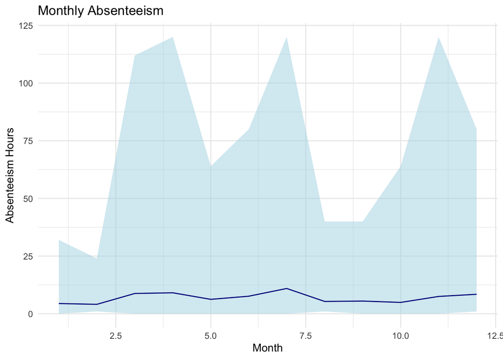

```r
ggplot(monthly_absenteeism_summary, aes(x=Month.of.absence, y=avg_absences)) +
  geom_ribbon(aes(ymin=min_absences, ymax=max_absences), fill="lightblue", alpha=0.5) +
  geom_line(color="darkblue") +
  labs(title="Monthly Absenteeism", x="Month", y="Absenteeism Hours") +
  theme_minimal()
```

In this chart: - `ggplot()` lays the foundation with `Month.of.absence` on the x-axis and `avg_absences` on the y-axis. - `geom_ribbon()` draws the ribbon representing the range from `min_absences` to `max_absences`. - `geom_line()` plots the average absenteeism across months. - The `labs()` function adds relevant titles and axis labels. - Aesthetically, `theme_minimal()` provides a clean and refined design.

However, as the plot might look slightly odd, examining outliers can often help clarify the picture.

### **Step 5: Boxplot of Absenteeism Hours by Month**

Boxplots offer a concise visualization of distribution, spread, and potential outliers within data. Here’s how the distribution of absenteeism hours for each month looks:

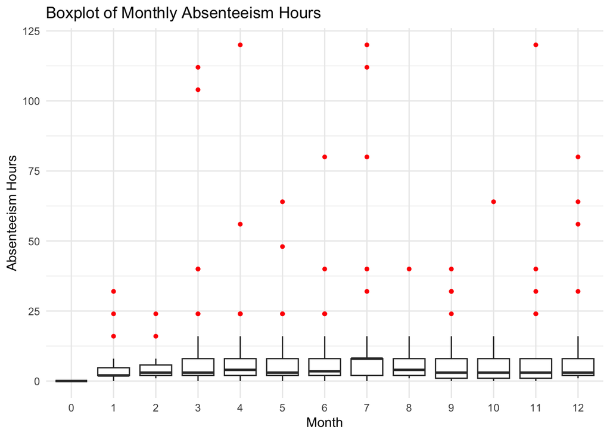

```r
ggplot(absenteeism_data, aes(x=factor(Month.of.absence), y=Absenteeism.time.in.hours)) +
  geom_boxplot(outlier.color="red", outlier.shape=16) +
  labs(title="Boxplot of Monthly Absenteeism Hours", x="Month", y="Absenteeism Hours") +
  theme_minimal()
```

In this visualization: - The dataset `absenteeism_data` is referenced, and aesthetic mappings set the `Month.of.absence` on the x-axis and the `Absenteeism.time.in.hours` on the y-axis. - `geom_boxplot()` creates the boxplot where: - The central line in each box displays the median. - The edges of the box indicate the first and third quartiles. - The whiskers provide a range, with outliers plotted in red.

## Part 4

In step 5, we observe numerous outliers in our data. Outliers can distort our understanding of the data and impact the accuracy of statistical analyses. One common technique to identify outliers is the Tukey method.

### Tukey’s Method for Identifying Outliers

The Tukey method defines outliers as values that fall outside the whiskers in a box plot. Specifically:

- Values below $Q1 - 1.5 \times IQR$
- Values above $Q3 + 1.5 \times IQR$

Here, $Q1$ represents the first quartile, $Q3$ is the third quartile, and $IQR$ stands for the interquartile range, which is calculated as $Q3 - Q1$.

### R Implementation: Identifying and Removing Outliers

Let’s dive into the R code to implement the Tukey method.

**Calculate IQR for Each Month**

```r
# Calculate the IQR for Absenteeism.time.in.hours for each month
iqr_data <- absenteeism_data %>%
filter(Month.of.absence!=0) %>%
group_by(Month.of.absence) %>%
summarise(Q1 = quantile(Absenteeism.time.in.hours, 0.25),
          Q3 = quantile(Absenteeism.time.in.hours, 0.75)) %>%
mutate(IQR = Q3 - Q1,
       Lower_Bound = Q1 - 1.5*IQR,
       Upper_Bound = Q3 + 1.5*IQR)
```

This code does the following:

1. Filters out entries with a month value of ‘0’.
2. Groups data by `Month.of.absence`.
3. Calculates the first (Q1) and third quartiles (Q3) for each month.
4. Computes the IQR and determines the lower and upper bounds for outliers.

```r
head(iqr_data)
```

```
## # A tibble: 6 × 6
##   Month.of.absence    Q1    Q3   IQR Lower_Bound Upper_Bound
##              <int> <dbl> <dbl> <dbl>       <dbl>       <dbl>
## 1                1     2  4.75  2.75       -2.12        8.88
## 2                2     2  5.75  3.75       -3.62       11.4
## 3                3     2  8     6          -7          17
## 4                4     2  8     6          -7          17
## 5                5     2  8     6          -7          17
## 6                6     2  8     6          -7          17
```

### Filtering Outliers from the Data

```r
# Join the iqr_data with absenteeism_data and filter out outliers
filtered_data <- absenteeism_data %>%
  filter(Month.of.absence!=0) %>%
  left_join(iqr_data, by = "Month.of.absence") %>%
  filter(Absenteeism.time.in.hours >= Lower_Bound &
           Absenteeism.time.in.hours <= Upper_Bound) %>%
  select(-c(Q1, Q3, IQR, Lower_Bound, Upper_Bound))
```

After calculating the outlier bounds, this code:

1. Merges the IQR data with the main dataset.
2. Retains only data within the non-outlier range.
3. Removes unnecessary columns.

### Monthly Summary Post Outlier Removal

```r
# Summarize data for each month after removing outliers
monthly_absenteeism_summary_no_outliers <- filtered_data %>%
  group_by(Month.of.absence) %>%
  summarise(
    avg_absences = mean(Absenteeism.time.in.hours),
    max_absences = max(Absenteeism.time.in.hours),
    min_absences = min(Absenteeism.time.in.hours)
  )
```

This summarized data offers insights into:

1. Average absenteeism hours (`avg_absences`).
2. Maximum absenteeism hours (`max_absences`).
3. Minimum absenteeism hours (`min_absences`).

```r
knitr::kable(monthly_absenteeism_summary_no_outliers)
```

| Month.of.absence | avg_absences | max_absences | min_absences |
| --- | --- | --- | --- |
| 1 | 3.191489 | 8 | 0 |
| 2 | 3.628571 | 8 | 1 |
| 3 | 5.197531 | 16 | 0 |
| 4 | 4.468085 | 16 | 0 |
| 5 | 4.000000 | 16 | 0 |
| 6 | 4.469388 | 16 | 0 |
| 7 | 5.645161 | 16 | 0 |
| 8 | 4.679245 | 16 | 1 |
| 9 | 3.346939 | 16 | 0 |
| 10 | 4.071429 | 16 | 0 |
| 11 | 4.017241 | 8 | 0 |
| 12 | 4.044444 | 16 | 1 |

## Part 5

### **Step 6: Further Analysis Using Cleaned Data**

*Objective*: Having eliminated the distortive effects of outliers from our dataset, we can now engage in deeper statistical analyses or predictive modeling. This can help businesses identify patterns, predict future absenteeism, or understand underlying causes.

1. **Statistical Summary of Cleaned Data**:

```r
summary(filtered_data$Absenteeism.time.in.hours)
```

```
##    Min. 1st Qu.  Median    Mean 3rd Qu.    Max.
##   0.000   2.000   3.000   4.278   8.000  16.000
```

This code produces a statistical summary of the absenteeism hours in the cleaned dataset, offering insights such as the mean, median, min, max, and the 1st and 3rd quartiles.

2. **Correlation Analysis**:

   Examining if there’s any significant correlation between absenteeism hours and other variables in the dataset.

```r
cor_matrix <- filtered_data %>% select(-Month.of.absence,-ID) %>% cor()
```

Correlation Heatmap of Filtered Data

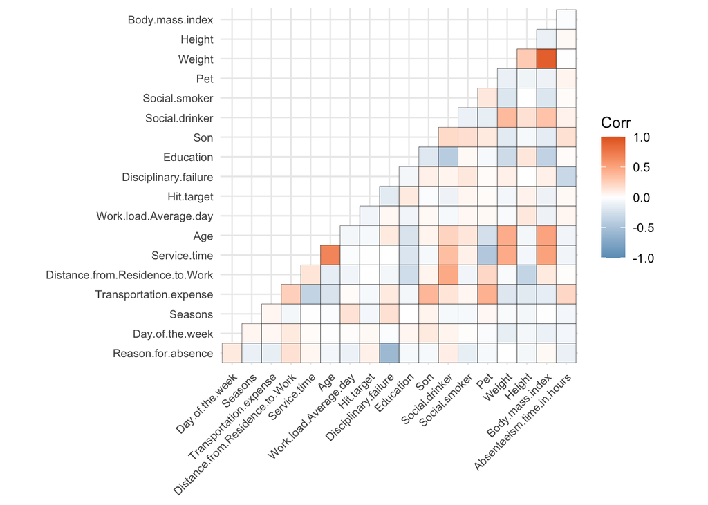

```r
pacman::p_load("ggcorrplot")

# Plot the correlation heatmap
ggcorrplot(cor_matrix,
           method = "square",
           type = "lower",
           lab = FALSE,
           tl.cex = 8,
           outline = TRUE,
           colors = c("#6D9EC1", "white", "#E46726"))
```

3. **Regression Analysis**:

   We can predict absenteeism hours based on other attributes using regression analysis.

```r
model <- lm(avg_absences ~ Month.of.absence, data=monthly_absenteeism_summary_no_outliers)
summary(model)
```

```
##
## Call:
## lm(formula = avg_absences ~ Month.of.absence, data = monthly_absenteeism_summary_no_outliers)
##
## Residuals:
##     Min      1Q  Median      3Q     Max
## -0.9884 -0.3304 -0.2034  0.3046  1.4106
##
## Coefficients:
##                  Estimate Std. Error t value Pr(>|t|)
## (Intercept)       4.17074    0.46141   9.039 3.98e-06 ***
## Month.of.absence  0.00911    0.06269   0.145    0.887
## ---
## Signif. codes:  0 '***' 0.001 '**' 0.01 '*' 0.05 '.' 0.1 ' ' 1
##
## Residual standard error: 0.7497 on 10 degrees of freedom
## Multiple R-squared:  0.002107,   Adjusted R-squared:  -0.09768
## F-statistic: 0.02112 on 1 and 10 DF,  p-value: 0.8873
```

### Visualization of Monthly Absenteeism without Outliers

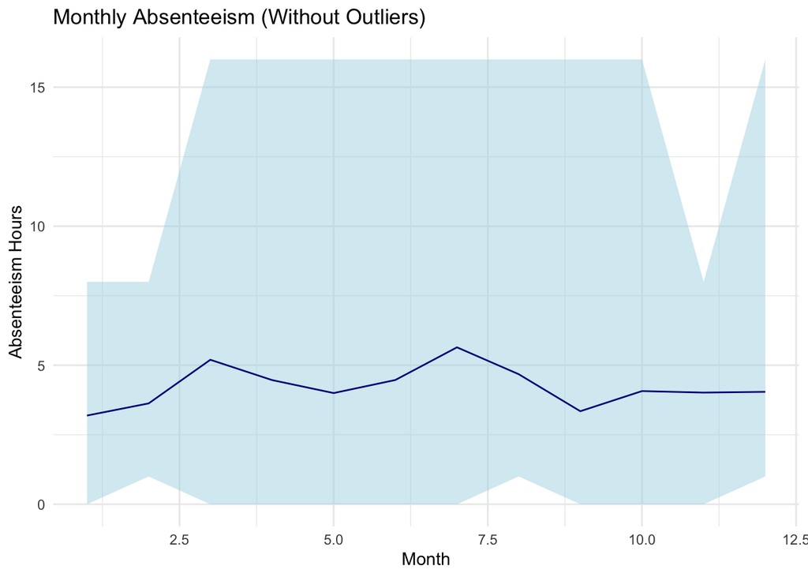

```r
ggplot(monthly_absenteeism_summary_no_outliers, aes(x=Month.of.absence, y=avg_absences)) +
  geom_ribbon(aes(ymin=min_absences, ymax=max_absences), fill="lightblue", alpha=0.5) +
  geom_line(color="darkblue") +
  labs(title="Monthly Absenteeism (Without Outliers)", x="Month", y="Absenteeism Hours") +
  theme_minimal()
```

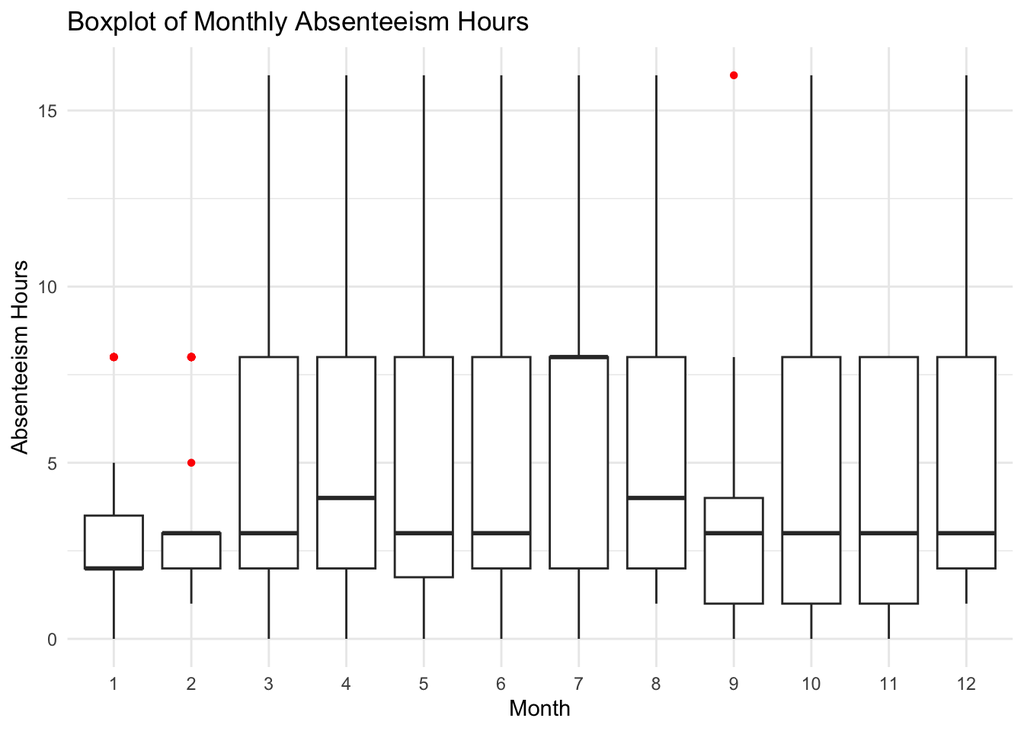

```r
ggplot(filtered_data, aes(x=factor(Month.of.absence), y=Absenteeism.time.in.hours)) +
  geom_boxplot(outlier.color="red", outlier.shape=16) +
  labs(title="Boxplot of Monthly Absenteeism Hours", x="Month", y="Absenteeism Hours") +
  theme_minimal()
```

### **Interpretation and Recommendations**

*Objective*: After completing the analyses, it’s essential to draw conclusions and offer actionable recommendations for businesses.

1. **Interpretation**:
   - Determine which months have the highest and lowest average absenteeism.
   - Identify any variables that are significantly correlated with absenteeism.
   - From the regression analysis, find out which variables have a strong influence on predicting absenteeism hours.
2. **Recommendations**:
   - If certain months consistently exhibit high absenteeism, consider deploying wellness programs or incentives during these periods.
   - For variables significantly influencing absenteeism, implement strategies to mitigate their impact. For instance, if a certain department has a high correlation with absenteeism, consider department-specific interventions.
   - Continuously monitor and update the predictive model to adapt to changing patterns of absenteeism.

**Presentation to Stakeholders**

*Objective*: It’s vital to communicate findings, interpretations, and recommendations to stakeholders in a concise and clear manner.

1. **Prepare Visual Aids**: Utilize plots, charts, and tables to illustrate the key findings. Data visualization tools can be instrumental in making data-driven stories more compelling.
2. **Highlight Key Findings**: Begin the presentation by showcasing the primary findings, ensuring stakeholders immediately understand the core message.
3. **Discuss Recommendations**: After presenting findings, transition into the actionable recommendations. This part of the presentation should be solution-oriented.
4. **Engage in a Q&A Session**: Allocate time for questions and answers, allowing stakeholders to seek clarifications or delve deeper into specific areas.
[^1]: Martiniano, Andrea and Ferreira, Ricardo. (2018). Absenteeism at work. UCI Machine Learning Repository. https://doi.org/10.24432/C5X882.